# Section 3.4 R Code and Analysis

## The `Student Performance` Example

In this final section we illustrate the practical implementation of the variable-selection and shrinkage methods developed earlier, using a real data example.

The analysis is based on the `student-mat.csv` data set, which contains information on student achievement in secondary education at two Portuguese schools. The original study is described in:

> Cortez, P., & Silva, A. M. G. (2008). Using data mining to predict secondary school student performance. *Proceedings of the 5th Annual Future Business Technology Conference*.

The data are publicly available from the UCI Machine Learning Repository:  
[Student Performance data set](https://archive.ics.uci.edu/dataset/320/student+performance).

The variables in the data set are the following:

- `school` – student’s school (*binary*: `GP` – Gabriel Pereira or `MS` – Mousinho da Silveira)
- `sex` – student’s sex (*binary*: `F` – female or `M` – male)
- `age` – student’s age (*numeric*: from 15 to 22)
- `address` – home address type (*binary*: `U` – urban or `R` – rural)
- `famsize` – family size (*binary*: `LE3` – ≤ 3 or `GT3` – > 3)
- `Pstatus` – parent’s cohabitation status (*binary*: `T` – living together or `A` – apart)
- `Medu` – mother’s education (*numeric*: 0 – none, 1 – primary (4th grade), 2 – 5th–9th grade, 3 – secondary, 4 – higher education)
- `Fedu` – father’s education (*numeric*: same coding as `Medu`)
- `Mjob` – mother’s occupation (*nominal*: `teacher`, `health`, `services`, `at_home`, `other`)
- `Fjob` – father’s occupation (*nominal*: same categories as `Mjob`)
- `reason` – reason for choosing the school (*nominal*: `home`, `reputation`, `course`, `other`)
- `guardian` – student’s guardian (*nominal*: `mother`, `father`, `other`)
- `traveltime` – home-to-school travel time (*numeric*: 1 – <15 min, 2 – 15–30 min, 3 – 30–60 min, 4 – >1 hour)
- `studytime` – weekly study time (*numeric*: 1 – <2 h, 2 – 2–5 h, 3 – 5–10 h, 4 – >10 h)
- `failures` – number of past class failures (*numeric*: *n* if 1 ≤ *n* < 3, else 4)
- `schoolsup` – extra educational support (*binary*: `yes`/`no`)
- `famsup` – family educational support (*binary*: `yes`/`no`)
- `paid` – extra paid classes in the course subject (*binary*: `yes`/`no`)
- `activities` – extra-curricular activities (*binary*: `yes`/`no`)
- `nursery` – attended nursery school (*binary*: `yes`/`no`)
- `higher` – wants to take higher education (*binary*: `yes`/`no`)
- `internet` – Internet access at home (*binary*: `yes`/`no`)
- `romantic` – in a romantic relationship (*binary*: `yes`/`no`)
- `famrel` – quality of family relationships (*numeric*: 1 – very bad to 5 – excellent)
- `freetime` – free time after school (*numeric*: 1 – very low to 5 – very high)
- `goout` – going out with friends (*numeric*: 1 – very low to 5 – very high)
- `Dalc` – workday alcohol consumption (*numeric*: 1 – very low to 5 – very high)
- `Walc` – weekend alcohol consumption (*numeric*: 1 – very low to 5 – very high)
- `health` – current health status (*numeric*: 1 – very bad to 5 – very good)
- `absences` – number of school absences (*numeric*: 0 to 93)
- `G1` – first-period grade (*numeric*: 0 to 20)
- `G2` – second-period grade (*numeric*: 0 to 20)
- `G3` – final grade (*numeric*: 0 to 20; the response variable)

```r
stu_performance0 <- read.csv2("student-mat.csv", header = TRUE)
```

Our goal is to predict the final grade (`G3`) using the penalized regression methods studied in this chapter. Because standard ridge and lasso do not handle categorical predictors directly (a group-lasso formulation would be required), we restrict attention to the numeric predictors only.

```r
## Keep only numeric predictors
stu_performance <- stu_performance0[, -c(1, 2, 4, 5, 6, 9, 10, 11, 12, 16, 17, 18, 19, 20, 21, 22, 23, 31, 32)]

## Rename the response
names(stu_performance)[14] <- "Grades"
head(stu_performance)
```

```
##   age Medu Fedu traveltime studytime failures famrel freetime goout Dalc Walc
## 1  18    4    4          2         2        0      4        3     4    1    1
## 2  17    1    1          1         2        0      5        3     3    1    1
## 3  15    1    1          1         2        3      4        3     2    2    3
## 4  15    4    2          1         3        0      3        2     2    1    1
## 5  16    3    3          1         2        0      4        3     2    1    2
## 6  16    4    3          1         2        0      5        4     2    1    2
##   health absences Grades
## 1      3        6      6
## 2      3        4      6
## 3      3       10     10
## 4      5        2     15
## 5      5        4     10
## 6      5       10     15
```

```r
n <- nrow(stu_performance)          # sample size
p <- ncol(stu_performance) - 1      # number of predictors (excluding intercept)
```

We begin by fitting the full linear model that includes every numeric predictor:

```r
performance.full = lm(Grades ~ ., data=stu_performance)
summary(performance.full)
```

```
##
## Call:
## lm(formula = Grades ~ ., data = stu_performance)
##
## Residuals:
##      Min       1Q   Median       3Q      Max
## -12.2769  -2.1753   0.4053   2.7927   8.7122
##
## Coefficients:
##             Estimate Std. Error t value Pr(>|t|)
## (Intercept) 13.53702    3.33724   4.056 6.05e-05 ***
## age         -0.25623    0.17880  -1.433  0.15268
## Medu         0.58494    0.25650   2.280  0.02313 *
## Fedu        -0.09135    0.25465  -0.359  0.72000
## traveltime  -0.40184    0.31439  -1.278  0.20197
## studytime    0.26583    0.26903   0.988  0.32373
## failures    -1.83146    0.31201  -5.870 9.49e-09 ***
## famrel       0.28018    0.24537   1.142  0.25422
## freetime     0.34139    0.23096   1.478  0.14021
## goout       -0.62638    0.22179  -2.824  0.00499 **
## Dalc        -0.13723    0.32034  -0.428  0.66862
## Walc         0.35312    0.23834   1.482  0.13928
## health      -0.17429    0.15620  -1.116  0.26521
## absences     0.03197    0.02760   1.158  0.24745
## ---
## Signif. codes:  0 '***' 0.001 '**' 0.01 '*' 0.05 '.' 0.1 ' ' 1
##
## Residual standard error: 4.211 on 381 degrees of freedom
## Multiple R-squared:  0.183,  Adjusted R-squared:  0.1551
## F-statistic: 6.564 on 13 and 381 DF,  p-value: 2.525e-11
```

A simple (but inefficient) approach to model selection is to compare the full model with a reduced model that retains only the apparently significant variables, *using a partial F-test*:

```r
performance.red = lm(Grades ~ failures + goout + Medu, data=stu_performance)

## Model comparison based on a partial F test
anova(performance.red, performance.full)
```

```
## Analysis of Variance Table
##
## Model 1: Grades ~ failures + goout + Medu
## Model 2: Grades ~ age + Medu + Fedu + traveltime + studytime + failures +
##     famrel + freetime + goout + Dalc + Walc + health + absences
##   Res.Df    RSS Df Sum of Sq     F Pr(>F)
## 1    391 6956.9
## 2    381 6756.7 10    200.22 1.129  0.339
```

In this particular case we fail to reject the null hypothesis, so the reduced model is preferred by the F-test. However, this ad-hoc strategy is neither systematic nor optimal. We therefore turn to formal search algorithms that explore the model space while applying an explicit complexity penalty.

#### Subset Selection via Level-wise algorithms & the `leaps` package

```r
library(leaps)
regsubsets_model <- regsubsets(Grades ~ ., data = stu_performance, nvmax = p)
rs <- summary(regsubsets_model)
```

The object `rs` stores the information criteria for every model examined. By default `regsubsets` considers models of size up to 8; we have overridden this limit with `nvmax = p` so that all model sizes from 1 to 13 are evaluated.

Below we extract the $R^2$, Adjusted $R^2$, $AIC$, $BIC$ and $C_p$-Mallows criteria for the 13 models that have been evaluated:

```r
## Extract the models' R^2
rs$rsq
```

```
##  [1] 0.1298989 0.1483134 0.1587670 0.1633698 0.1668323 0.1696634 0.1724079
##  [8] 0.1746913 0.1773575 0.1800384 0.1823149 0.1827012 0.1829771
```

The best model is the 13th model (as expected).

```r
## Extract the models' Adjusted R^2
rs$adjr2
```

```
##  [1] 0.1276849 0.1439681 0.1523125 0.1547890 0.1561232 0.1568231 0.1574385
##  [8] 0.1575865 0.1581269 0.1586853 0.1588305 0.1570269 0.1550997
```

The best model is the 11th model.

```r
## Extract the models' Cp Mallows
rs$cp
```

```
##  [1] 14.751803  8.164618  5.289832  5.143431  5.528772  6.208548  6.928720
##  [8]  7.863899  8.620578  9.370388 10.308796 12.128682 14.000000
```

The best model is the 4th model.

```r
## Extract the models' BIC
rs$bic
```

```
##  [1] -43.004859 -45.475340 -44.374670 -40.562949 -36.222213 -31.587827
##  [7] -26.916684 -22.029154 -17.328400 -12.638892  -7.758187  -1.965927
## [13]   3.879571
```

The best model is the 2nd model.

The matrix `rs$which` indicates which variables appear in each model (`TRUE = included`):

```r
rs$which
```

```
##    (Intercept)   age  Medu  Fedu traveltime studytime failures famrel freetime
## 1         TRUE FALSE FALSE FALSE      FALSE     FALSE     TRUE  FALSE    FALSE
## 2         TRUE FALSE  TRUE FALSE      FALSE     FALSE     TRUE  FALSE    FALSE
## 3         TRUE FALSE  TRUE FALSE      FALSE     FALSE     TRUE  FALSE    FALSE
## 4         TRUE FALSE  TRUE FALSE      FALSE     FALSE     TRUE  FALSE     TRUE
## 5         TRUE FALSE  TRUE FALSE       TRUE     FALSE     TRUE  FALSE     TRUE
## 6         TRUE FALSE  TRUE FALSE       TRUE     FALSE     TRUE  FALSE     TRUE
## 7         TRUE  TRUE  TRUE FALSE       TRUE     FALSE     TRUE  FALSE     TRUE
## 8         TRUE  TRUE  TRUE FALSE       TRUE     FALSE     TRUE  FALSE     TRUE
## 9         TRUE  TRUE  TRUE FALSE       TRUE     FALSE     TRUE   TRUE     TRUE
## 10        TRUE  TRUE  TRUE FALSE       TRUE     FALSE     TRUE   TRUE     TRUE
## 11        TRUE  TRUE  TRUE FALSE       TRUE      TRUE     TRUE   TRUE     TRUE
## 12        TRUE  TRUE  TRUE FALSE       TRUE      TRUE     TRUE   TRUE     TRUE
## 13        TRUE  TRUE  TRUE  TRUE       TRUE      TRUE     TRUE   TRUE     TRUE
##    goout  Dalc  Walc health absences
## 1  FALSE FALSE FALSE  FALSE    FALSE
## 2  FALSE FALSE FALSE  FALSE    FALSE
## 3   TRUE FALSE FALSE  FALSE    FALSE
## 4   TRUE FALSE FALSE  FALSE    FALSE
## 5   TRUE FALSE FALSE  FALSE    FALSE
## 6   TRUE FALSE  TRUE  FALSE    FALSE
## 7   TRUE FALSE FALSE  FALSE     TRUE
## 8   TRUE FALSE  TRUE  FALSE     TRUE
## 9   TRUE FALSE  TRUE   TRUE    FALSE
## 10  TRUE FALSE  TRUE   TRUE     TRUE
## 11  TRUE FALSE  TRUE   TRUE     TRUE
## 12  TRUE  TRUE  TRUE   TRUE     TRUE
## 13  TRUE  TRUE  TRUE   TRUE     TRUE
```

For example, Model 1 only contains `failures`, and the `intercept.`

We can also compute AIC and BIC “by hand” for the sequence of models:

```r
msize <- 1:p
par(mfrow = c(1, 2))
Aic <- n * log(rs$rss / n) + 2 * msize
Bic <- n * log(rs$rss / n) + msize * log(n)
```

```r
Aic
```

```
##  [1] 1148.427 1141.978 1139.100 1138.932 1139.294 1139.950 1140.642 1141.551
##  [9] 1142.272 1142.983 1143.885 1145.698 1147.565
```

AIC chooses the 4th model.

```r
Bic
```

```
##  [1] 1152.406 1149.936 1151.036 1154.848 1159.189 1163.823 1168.494 1173.382
##  [9] 1178.082 1182.772 1187.653 1193.445 1199.290
```

As we saw before, BIC selects the 2nd model. We can also plot the results for the various models. So, we have

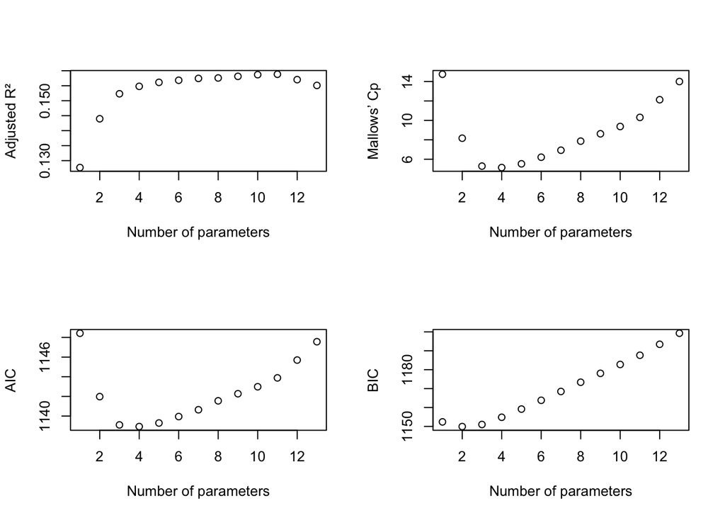

```r
par(mfrow = c(2, 2))
plot(msize, rs$adjr2, xlab = "Number of parameters", ylab = "Adjusted R²")
plot(msize, rs$cp,    xlab = "Number of parameters", ylab = "Mallows’ Cp")
plot(msize, Aic,      xlab = "Number of parameters", ylab = "AIC")
plot(msize, Bic,      xlab = "Number of parameters", ylab = "BIC")
```

```r
cbind(rs$which[which.min(Aic),], rs$which[which.min(Bic), ])
```

```
##              [,1]  [,2]
## (Intercept)  TRUE  TRUE
## age         FALSE FALSE
## Medu         TRUE  TRUE
## Fedu        FALSE FALSE
## traveltime  FALSE FALSE
## studytime   FALSE FALSE
## failures     TRUE  TRUE
## famrel      FALSE FALSE
## freetime     TRUE FALSE
## goout        TRUE FALSE
## Dalc        FALSE FALSE
## Walc        FALSE FALSE
## health      FALSE FALSE
## absences    FALSE FALSE
```

(Note that the BIC reported by leaps differs from our hand calculation by a constant; the ranking of models is therefore identical.)

```r
cbind(rs$bic, Bic, rs$bic - Bic)
```

```
##                       Bic
##  [1,] -43.004859 1152.406 -1195.411
##  [2,] -45.475340 1149.936 -1195.411
##  [3,] -44.374670 1151.036 -1195.411
##  [4,] -40.562949 1154.848 -1195.411
##  [5,] -36.222213 1159.189 -1195.411
##  [6,] -31.587827 1163.823 -1195.411
##  [7,] -26.916684 1168.494 -1195.411
##  [8,] -22.029154 1173.382 -1195.411
##  [9,] -17.328400 1178.082 -1195.411
## [10,] -12.638892 1182.772 -1195.411
## [11,]  -7.758187 1187.653 -1195.411
## [12,]  -1.965927 1193.445 -1195.411
## [13,]   3.879571 1199.290 -1195.411
```

To examine the second- and third-best models we request the three best models of each size:

```r
regsubsets_model.1 = regsubsets(Grades ~ ., data=stu_performance, nbest = 3, nvmax = p)
rs.1 = summary(regsubsets_model.1)
#rs.1$which
msize.1 = apply(rs.1$which, 1, sum) - 1
```

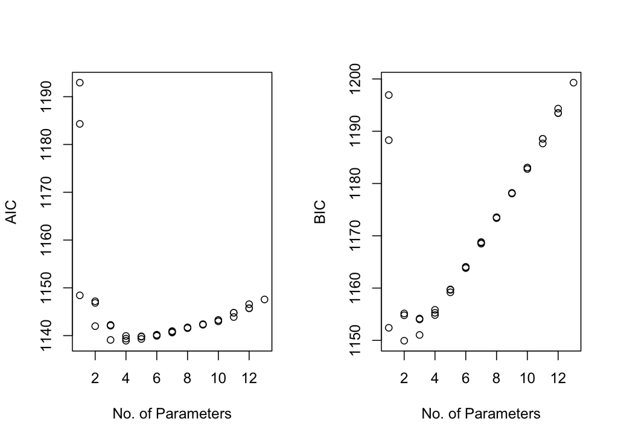

```r
par(mfrow=c(1,2))
Aic.1 = n*log(rs.1$rss/n) + 2*msize.1
Bic.1 = n*log(rs.1$rss/n) + msize.1*log(n)
plot(msize.1, Aic.1, xlab="No. of Parameters", ylab = "AIC")
plot(msize.1, Bic.1, xlab="No. of Parameters", ylab = "BIC")
```

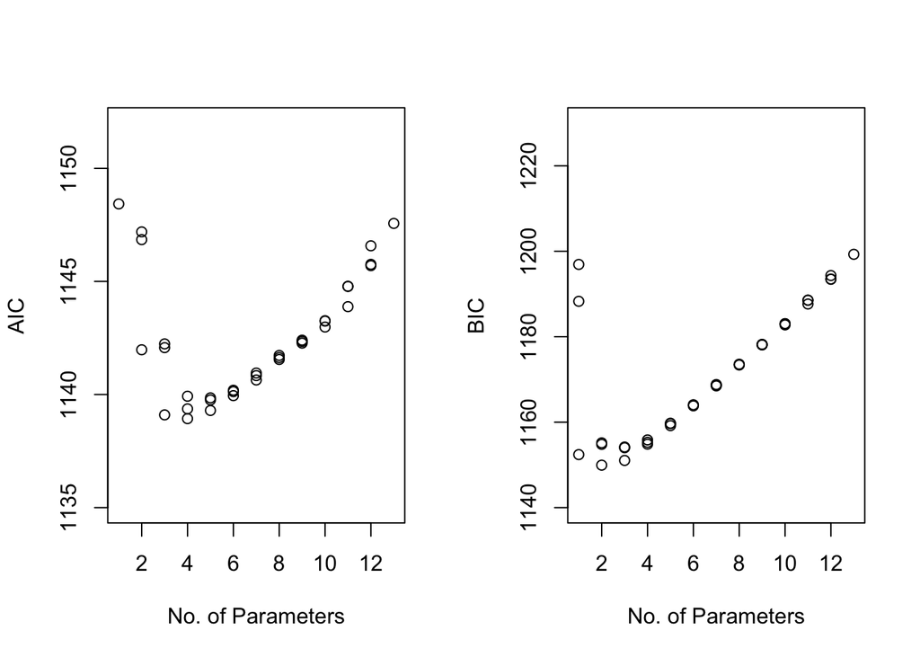

```r
par(mfrow=c(1,2))
plot(msize.1, Aic.1, ylim = c(1135, 1152), xlab="No. of Parameters", ylab = "AIC")
plot(msize.1, Bic.1, ylim = c(1140, 1230), xlab="No. of Parameters", ylab = "BIC")
```

```r
## Top three models by AIC
rs.1$which[order(Aic.1)[1:3], ]
```

```
##   (Intercept)   age Medu  Fedu traveltime studytime failures famrel freetime
## 4        TRUE FALSE TRUE FALSE      FALSE     FALSE     TRUE  FALSE     TRUE
## 3        TRUE FALSE TRUE FALSE      FALSE     FALSE     TRUE  FALSE    FALSE
## 5        TRUE FALSE TRUE FALSE       TRUE     FALSE     TRUE  FALSE     TRUE
##   goout  Dalc  Walc health absences
## 4  TRUE FALSE FALSE  FALSE    FALSE
## 3  TRUE FALSE FALSE  FALSE    FALSE
## 5  TRUE FALSE FALSE  FALSE    FALSE
```

```r
## Top three models by BIC
rs.1$which[order(Bic.1)[1:3], ]
```

```
##   (Intercept)   age  Medu  Fedu traveltime studytime failures famrel freetime
## 2        TRUE FALSE  TRUE FALSE      FALSE     FALSE     TRUE  FALSE    FALSE
## 3        TRUE FALSE  TRUE FALSE      FALSE     FALSE     TRUE  FALSE    FALSE
## 1        TRUE FALSE FALSE FALSE      FALSE     FALSE     TRUE  FALSE    FALSE
##   goout  Dalc  Walc health absences
## 2 FALSE FALSE FALSE  FALSE    FALSE
## 3  TRUE FALSE FALSE  FALSE    FALSE
## 1 FALSE FALSE FALSE  FALSE    FALSE
```

#### Subset Selection via the `step` Fucntion

The `step` function implements forward, backward, and stepwise search. By default it uses AIC; setting `k = log(n)` yields BIC.

```r
## Stepwise Selection with AIC

stepAIC = step(performance.full, trace=0, direction="both")
#stepAIC = step(performance.full, direction="both")
```

```r
## Stepwise Selection with BIC

n = dim(stu_performance)[1]
stepBIC = step(performance.full, trace=0, direction="both", k=log(n))
```

The selected variables can be extracted as follows:

```r
sel.var.AIC = attr(stepAIC$terms, "term.labels")
sel.var.BIC = attr(stepBIC$terms, "term.labels")
sel.var.AIC
```

```
## [1] "Medu"     "failures" "freetime" "goout"
```

```r
length(sel.var.AIC)
```

```
## [1] 4
```

```r
length(sel.var.BIC)
```

```
## [1] 2
```

```r
c("Medu", "failures","freetime", "goout") %in% sel.var.AIC
```

```
## [1] TRUE TRUE TRUE TRUE
```

```r
sel.var.BIC %in% sel.var.AIC
```

```
## [1] TRUE TRUE
```

#### LASSO and RIDGE Regression

The package `glmnet` implements both ridge ($\alpha = 0$) and lasso ($\alpha = 1$). Additional examples can be found at https://web.stanford.edu/~hastie/glmnet/glmnet_beta.html

```r
library(glmnet)
## The input in the glmnet function should be in matrix format:

X = as.matrix(stu_performance[, names(stu_performance) != "Grades"])
Y = stu_performance$Grades
```

We randomly split the data into an 80 % training set and a 20 % test set. Model selection and coefficient estimation are performed on the training data; predictive performance is evaluated on the held-out test set.

```r
## Training/ Testing Data Sets
set.seed(598)                       # for reproducibility
ntest  <- round(n * 0.2)
ntrain <- n - ntest
test.id <- sample(1:n, ntest)
Ytest  <- Y[test.id]
```

For reference we also fit the ordinary least-squares model on the training data and compute its test-set MSE:

```r
full.model <- lm(Y[-test.id] ~ ., data = stu_performance[-test.id, names(stu_performance) != "Grades"])
Ytest.pred <- predict(full.model, newdata = stu_performance[test.id, names(stu_performance) != "Grades"])
mean((Ytest - Ytest.pred)^2)
```

```
## [1] 22.31678
```

### Ridge Regression

Fit a set of ridge regression models using `glmnet` with the default $\lambda$ sequence. Selecting $\alpha=0$ to run a **ridge**

We plot the fitted output of the ridge regression. We can use the `xvar` argument to decide what is plotted on the x-axis. We can also label the curves with the variable index numbers simply by setting `label = TRUE`.

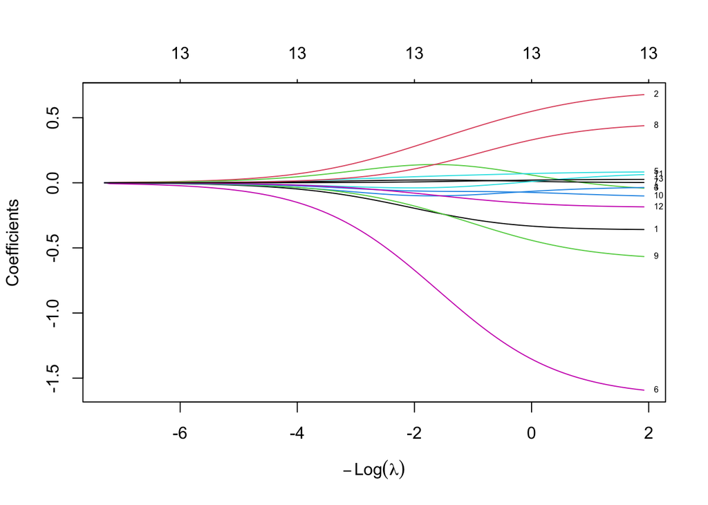

```r
ridge.lm = glmnet(X[-test.id, ], Y[-test.id], alpha = 0)
plot(ridge.lm , label = TRUE, xvar = "lambda")
```

We can obtain the $\lambda$ values

```r
length(ridge.lm$lambda)
```

```
## [1] 100
```

```r
## remove the length function to see the lambda values
```

and the coefficients :

```r
dim(ridge.lm $beta)       ## coefficients for  non-intercept predictors
```

```
## [1]  13 100
```

```r
length(ridge.lm $a0)      ## intercept
```

```
## [1] 100
```

```r
## You can also retrieve coefficients (including intercept) using coef(myridge)
dim(coef(ridge.lm ))
```

```
## [1]  14 100
```

```r
## The two coefficient matrices should be the same
sum((coef(ridge.lm ) - rbind(ridge.lm $a0, ridge.lm $beta))^2)
```

```
## [1] 0
```

How are the intercepts computed?

```r
k = 2;

## Compute the "intercept" by hand:
mean.ridge = apply(X[-test.id, ], 2, mean)  ## mean vector for training X
mean(Y[-test.id]) - sum(mean.ridge * ridge.lm $beta[, k])
```

```
## [1] 10.60974
```

```r
## Extract intercept from the estimated coefficients
ridge.lm$a0[k]            ## intercept for lambda = myridge$lambda[k]
```

```
##       s1
## 10.60974
```

```r
## Both approaches give the same value
sum((mean(Y[-test.id]) - mean.ridge %*% ridge.lm $beta  - ridge.lm $a0)^2)
```

```
## [1] 1.072851e-27
```

We can also choose `xvar="dev"` to *plot the fitted coefficients against the percent deviance*. This is the percent of deviance explained on the training data, and is a measure of complexity of the model. We can see that the coefficients do not change much after a point the but the coefficients start blowing up a bit.

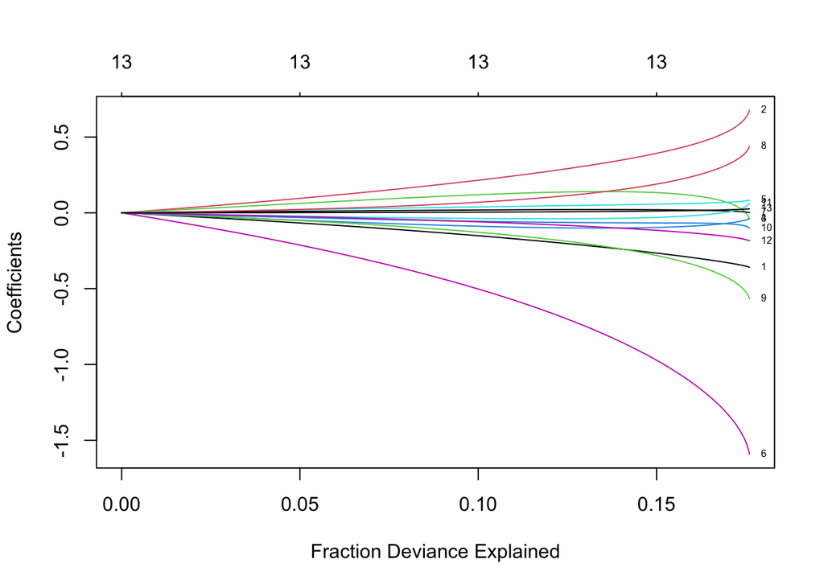

```r
plot(ridge.lm, xvar = "dev", label = TRUE)
```

#### Cross-Validation & Path Plot

If we want to use cross-validation to choose $\lambda$, then we can use the function `cv.glmnet`. This function is using a $K$-fold cross validation method to obtain the “optimal lambda”. The `cv.glmnet` has the attribute `nfolds` to select the number of folds we prefer, the option `foldid` to specify our own folds, and `type.measure` to choose the loss function (`deviance` or `mse` for squared loss, and `mae` for mean absolute error).

```r
ridge.cv = cv.glmnet(X[-test.id, ], Y[-test.id], alpha = 0)
## the default in nfolds is 10
```

Some basic output information can be obtained

```r
print(ridge.cv)
```

```
##
## Call:  cv.glmnet(x = X[-test.id, ], y = Y[-test.id], alpha = 0)
##
## Measure: Mean-Squared Error
##
##     Lambda Index Measure    SE Nonzero
## min   1.50    75   17.37 1.639      13
## 1se  46.96    38   19.01 2.014      13
```

As a side note, the `cv.glmnet` function allows parallel computing for large scale problems.

The results are stored in

`ridge.cv$cvm` mean CV errors `ridge.cv$cvsd`: standard errors of CVm

We can also plot the result of the `cv.glmnet`:

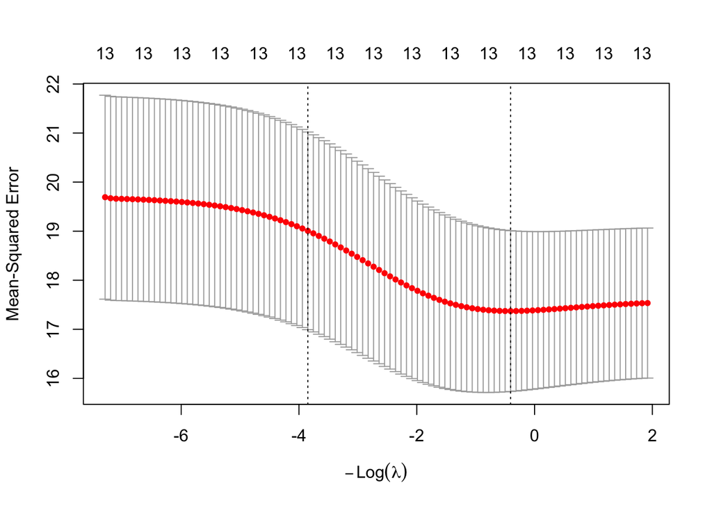

```r
plot(ridge.cv)
```

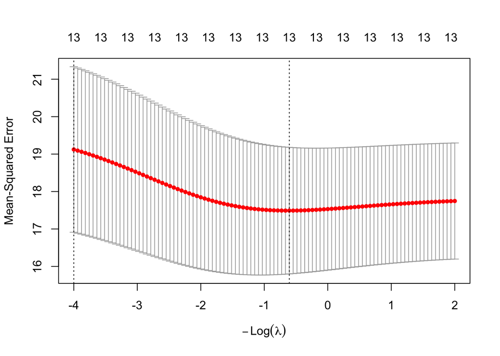

```r
lambda.seq = exp(seq(-2, 4, length=100))
ridge.cv.seq = cv.glmnet(X[-test.id,], Y[-test.id], alpha=0, lambda=lambda.seq)
plot(ridge.cv.seq)
```

Check how `lambda.min` and `lambda.1se` are computed.

```r
names(ridge.cv.seq)
```

```
##  [1] "lambda"     "cvm"        "cvsd"       "cvup"       "cvlo"
##  [6] "nzero"      "call"       "name"       "glmnet.fit" "lambda.min"
## [11] "lambda.1se" "index"
```

```r
## Find lambda.min
ridge.cv.seq$lambda.min
```

```
## [1] 1.833195
```

```r
ridge.cv.seq$lambda[which.min(ridge.cv.seq$cvm)]
```

```
## [1] 1.833195
```

```r
## Find lambda.1se
ridge.cv.seq$lambda.1se
```

```
## [1] 54.59815
```

```r
tmp.id = which.min(ridge.cv.seq$cvm)
max(ridge.cv.seq$lambda[ridge.cv.seq$cvm < ridge.cv.seq$cvm[tmp.id] + ridge.cv.seq$cvsd[tmp.id]])
```

```
## [1] 54.59815
```

##### Prediction

Next we apply the two ridge regression models—one with `lambda.min` and one with `lambda.1se` on a new *test* data set and report the corresponding **mean squared prediction errors**:

```r
ridge.lambda.pred = glmnet(X[-test.id,], Y[-test.id], alpha=0, lambda = lambda.seq)
```

```r
## Using the lambda.min
Ytest.ridge.min.pred = predict(ridge.lambda.pred, s = ridge.cv.seq$lambda.min, newx=X[test.id,])
mean((Ytest.ridge.min.pred - Y[test.id])^2)
```

```
## [1] 22.53208
```

```r
## Using lambda.1se
Ytest.ridge.1se.pred = predict(ridge.lambda.pred, s = ridge.cv.seq$lambda.1se, newx=X[test.id,])
mean((Ytest.ridge.1se.pred - Y[test.id])^2)
```

```
## [1] 25.47849
```

### LASSO Regression

If we want to use LASSO instead of Ridge, we need to set $\alpha=1$ in the `glmnet` function. In this case, we have

```r
lasso.lm = glmnet(X[-test.id,], Y[-test.id], alpha = 1)
```

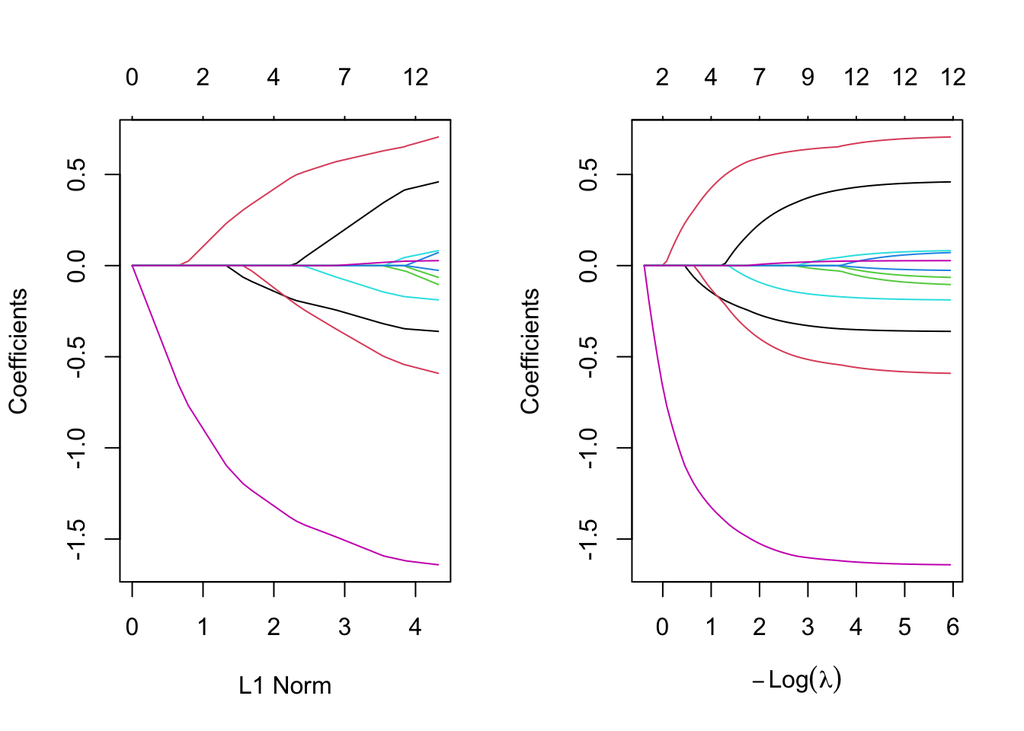

```r
par(mfrow = c(1, 2))
plot(lasso.lm, label=TRUE, xvar = "norm")   ## norm is the default value for xvar
plot(lasso.lm, label=TRUE, xvar = "lambda")
```

```r
par(mfrow=c(1,1))
```

We can extract the number of non-zero coefficients for each value of $\lambda$.

```r
lasso.lm$df
```

```
##  [1]  0  1  1  1  1  2  2  2  2  2  3  3  4  4  4  4  4  4  5  6  6  6  6  7  7
## [26]  7  7  7  7  7  7  7  7  7  9  9  9  9  9  9  9  9  9 10 12 12 12 12 12 12
## [51] 12 12 12 12 12 12 12 12 12 12 12 12 12 12 12 12 12 12 12
```

As with the ridge regression example, we can still use cross-validation by calling the `cv.glmnet`:

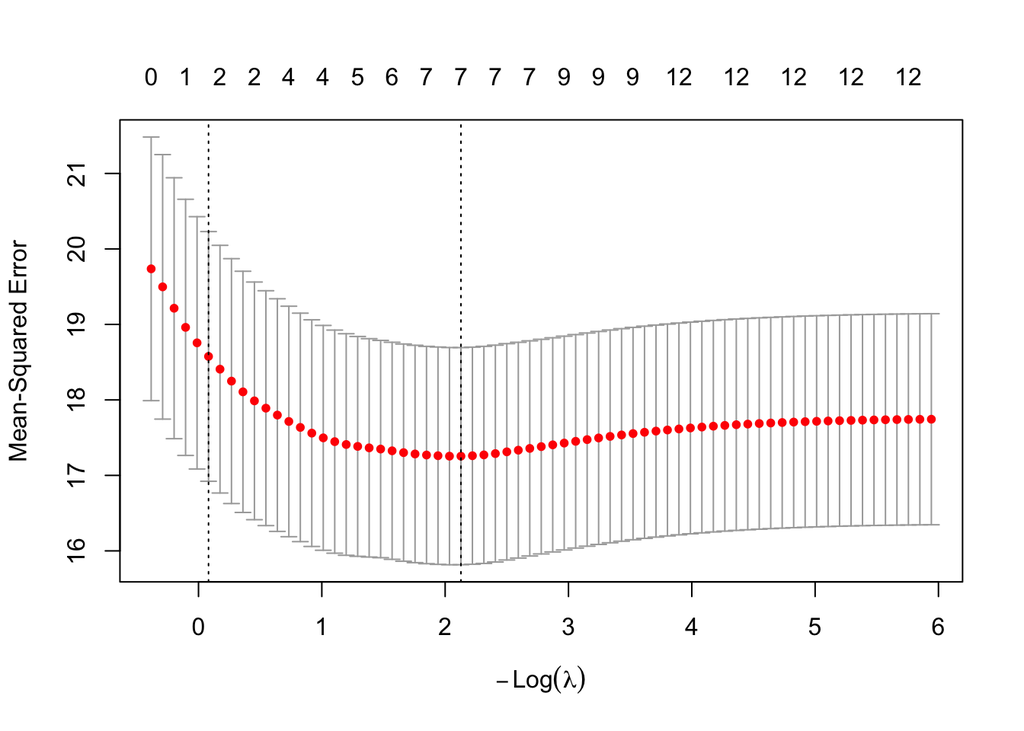

```r
lasso.cv = cv.glmnet(X[-test.id, ], Y[-test.id], alpha = 1)
plot(lasso.cv)
```

From the `cv.glmnet` object we can still compute `lambda.min` and `lambda.1se` in the same way as before:

```r
## Computing lambda.min
lasso.cv$lambda.min
```

```
## [1] 0.1190689
```

```r
## Computing lambda.1se
lasso.cv$lambda.1se
```

```
## [1] 0.9219072
```

We can also extract the LASSO coefficients:

```r
lasso.min.pred.coef = predict(lasso.lm, s=lasso.cv$lambda.min, type="coefficients");
lasso.1se.pred.coef = predict(lasso.lm, s=lasso.cv$lambda.1se, type="coefficients");
cbind(lasso.min.pred.coef, lasso.1se.pred.coef);
```

```
## 14 x 2 sparse Matrix of class "dgCMatrix"
##              s=0.1190689 s=0.9219072
## (Intercept) 14.920661406 10.75737536
## age         -0.281420530  .
## Medu         0.600006298  0.02508545
## Fedu         .            .
## traveltime   .            .
## studytime    .            .
## failures    -1.540566778 -0.76873824
## famrel       .            .
## freetime     0.254866691  .
## goout       -0.422725540  .
## Dalc         .            .
## Walc         .            .
## health      -0.103790831  .
## absences     0.008985155  .
```

```r
## number of variables selected (including the intercept)
sum(lasso.1se.pred.coef != 0)
```

```
## [1] 3
```

```r
sum(lasso.min.pred.coef != 0)
```

```
## [1] 8
```

```r
## names of selected non-intercept variables
row.names(lasso.1se.pred.coef)[which(lasso.1se.pred.coef != 0)[-1]]
```

```
## [1] "Medu"     "failures"
```

```r
row.names(lasso.min.pred.coef)[which(lasso.min.pred.coef != 0)[-1]]
```

```
## [1] "age"      "Medu"     "failures" "freetime" "goout"    "health"   "absences"
```

##### Prediction

Apply the two fitted models for prediction on test data:

```r
lasso.lambda.pred = glmnet(X[-test.id, ], Y[-test.id], alpha = 1)
```

```r
## Using the lambda.min
Ytest.lasso.min.pred = predict(lasso.lambda.pred, s = lasso.cv$lambda.min, newx = X[test.id,])
mean((Ytest.lasso.min.pred - Y[test.id])^2)
```

```
## [1] 22.301
```

```r
## Using lambda.1se
Ytest.lasso.1se.pred = predict(lasso.lambda.pred, s = lasso.cv$lambda.1se, newx=X[test.id,])
mean((Ytest.lasso.1se.pred - Y[test.id])^2)
```

```
## [1] 23.71601
```

### Debiasing via Refitting

A common post-processing step is to refit an ordinary least-squares model on the variables selected by the lasso (here using `lambda.1se`) and then use that unbiased estimator for prediction:

```r
lasso.coef.1se = predict(lasso.lambda.pred, s = lasso.cv$lambda.1se, type="coefficients")
variables.lasso = row.names(lasso.coef.1se)[which(lasso.coef.1se != 0)[-1]]
variables.lasso
```

```
## [1] "Medu"     "failures"
```

```r
tmp.X <- X[, colnames(X) %in% variables.lasso, drop = FALSE]

train.df <- data.frame(Y = Y[-test.id], tmp.X[-test.id, , drop = FALSE])
lasso.refit <- coef(lm(Y ~ ., data = train.df))

# prediction on the test set
Ytest.pred <- lasso.refit[1] + as.matrix(tmp.X[test.id, , drop = FALSE]) %*% lasso.refit[-1]
mean((Ytest.pred - Y[test.id])^2)
```

```
## [1] 21.77062
```

This refitted model often improves prediction accuracy relative to the original (biased) lasso estimator while retaining the sparsity pattern discovered by the $\ell_1$ penalty.